# Subsetting

GEOG 693g

Amy Hessl

25 October, 2019

### Motivation

Marsha has a large dataset of data on Springs in the United States. Though she doesn’t want to work with all the data right now, (just WV), she doesn’t want to delete the data either. Instead of making a copy of the file with just the WV data, can Marsha select the data for WV and ignore the rest? Can she select only springs with recent data?

How can Marsha work with subsets of data in R?

#### Questions

- How do I extract elements from a vector? Data frame? List?
- Can factors help me summarize data?
- How can I leave particular observations out of my analysis?

#### Objectives

- To be able to subset vectors, factors, matrices, lists, and data frames
- To be able to extract individual and multiple elements: by index, by name, using comparison operations
- To be able to skip and remove elements from various data structures.

#### Terms/Commands

- %in% - for matching specific elements in a vector
- all - matching all elements
- any - matching any of the elements
- logical operators (>, >=, ==, |, !)
- is.na, na.omit, is.finite - to deal with missing values
- rnorm() - generate randome values in the normal distribution
- [, [[, and $ - for subsetting

### Subsetting Vectors

R has many powerful subset operators. Mastering them will allow you to easily perform complex operations on any kind of dataset. There are six different ways we can subset any kind of object, and three different subsetting operators for the different data structures. Let’s start with the workhorse of R: a simple numeric vector.

```r
x <- c(5.4, 6.2, 7.1, 4.8, 7.5)
names(x) <- c('a', 'b', 'c', 'd', 'e')
x
```

```
##   a   b   c   d   e
## 5.4 6.2 7.1 4.8 7.5
```

#### Atomic vectors

In R, simple vectors containing character strings, numbers, or logical values are called atomic vectors because they can’t be further simplified.

So now that we’ve created a dummy vector to play with, how do we get at its contents?

#### Accessing elements using their indices

To extract elements of a vector we can give their corresponding index, starting from one:

```r
x[1]
```

```
##   a
## 5.4
```

It may look different, but the square brackets operator is a function. For vectors (and matrices), it means “get me the nth element”.

We can ask for multiple elements at once:

```r
x[c(1, 3)]
```

```
##   a   c
## 5.4 7.1
```

Or slices of the vector:

```r
x[1:4]
```

```
##   a   b   c   d
## 5.4 6.2 7.1 4.8
```

We can ask for the same element multiple times:

```r
x[c(1,1,3)]
```

```
##   a   a   c
## 5.4 5.4 7.1
```

If we ask for an index beyond the length of the vector, R will return a missing value:

```r
x[6]
```

[output not shown]

This is a vector of length one containing an NA, whose name is also NA. If we ask for the 0th element, we get an empty vector:

```r
x[0]
```

```
## named numeric(0)
```

**Vector numbering in R starts at 1** In many programming languages (C and Python, for example), the first element of a vector has an index of 0. In R, the first element is 1.

#### Skipping and removing elements

If we use a negative number as the index of a vector, R will return every element except for the one specified:

```r
x[-2]
```

```
##   a   c   d   e
## 5.4 7.1 4.8 7.5
```

We can skip multiple elements:

```r
x[c(-1,-5)]
```

```
##   b   c   d
## 6.2 7.1 4.8
```

#### Tip: Order of operations

A common trip up for novices occurs when trying to skip slices of a vector. It’s natural to try to negate a sequence like so:

```r
x[-1:3]
```

[output not shown]

Remember the order of operations. `:` is really a function. It takes its first argument as -1, and its second as 3, so generates the sequence of numbers: c(-1, 0, 1, 2, 3). The correct solution is to wrap that function call in brackets, so that the - operator applies to the result:

```r
x[-(1:3)]
```

```
##   d   e
## 4.8 7.5
```

To remove elements from a vector, we need to assign the result back into the variable:

```r
x <- x[-4]
x
```

```
##   a   b   c   e
## 5.4 6.2 7.1 7.5
```

> **Challenge 1**

Given the following code:

```r
x <- c(5.4, 6.2, 7.1, 4.8, 7.5)
names(x) <- c('a', 'b', 'c', 'd', 'e')
print(x)
```

```
##   a   b   c   d   e
## 5.4 6.2 7.1 4.8 7.5
```

Come up with at least 2 different commands that will produce the following output:

```
##   c   d   e
## 7.1 4.8 7.5
```

After you find 2 different commands, compare notes with your neighbor. Did you have different strategies?

#### Subsetting by name

We can extract elements by using their name, instead of extracting by index:

```r
x <- c(a=5.4, b=6.2, c=7.1, d=4.8, e=7.5) # we can name a vector 'on the fly'
x[c("a", "c")]
```

```
##   a   c
## 5.4 7.1
```

This is usually a much more reliable way to subset objects: the position of various elements can often change when chaining together subsetting operations, but the names will always remain the same!

#### Subsetting through logical operations

We can also use any logical vector (index) to subset:

```r
x[c(FALSE, FALSE, TRUE, FALSE, TRUE)]
```

```
##   c   e
## 7.1 7.5
```

Since *comparison* operators (e.g. >, <, ==) evaluate to logical vectors, we can also use them to succinctly subset vectors: the following statement gives the same result as the previous one.

```r
x[x > 7]
```

```
##   c   e
## 7.1 7.5
```

Breaking it down, this statement first evaluates `x>7`, generating a logical vector `c(FALSE, FALSE, TRUE, FALSE, TRUE)`, and then selects the elements of `x` corresponding to the TRUE values. We can use `==` to mimic the previous method of indexing by name (remember you have to use == rather than = for comparisons):

```r
x[names(x) == "a"]
```

```
##   a
## 5.4
```

#### Combining logical conditions

We often want to combine multiple logical criteria. For example, we might want to find all the countries that are located in Asia or Europe and have life expectancies within a certain range. Several operations for combining logical vectors exist in R:  
* `&`, the “logical AND” operator: returns TRUE if both the left and right are TRUE.  
* `|`, the “logical OR” operator: returns TRUE, if either the left or right (or both) are TRUE.  
You may sometimes see && and || instead of & and |. These two-character operators only look at the first element of each vector and ignore the remaining elements. In general, you should not use the two-character operators in data analysis; save them for programming, i.e. deciding whether to execute a statement.  
* `!`, the “logical NOT” operator: converts TRUE to FALSE and FALSE to TRUE. It can negate a single logical condition (eg !TRUE becomes FALSE), or a whole vector of conditions(eg !c(TRUE, FALSE) becomes c(FALSE, TRUE)).  
Additionally, you can compare the elements within a single vector using the `all` function (which returns TRUE if every element of the vector is TRUE) and the `any` function (which returns TRUE if one or more elements of the vector are TRUE).

> **Challenge**

Given the following code:

```r
x <- c(5.4, 6.2, 7.1, 4.8, 7.5)
names(x) <- c('a', 'b', 'c', 'd', 'e')
print(x)
```

```
##   a   b   c   d   e
## 5.4 6.2 7.1 4.8 7.5
```

Write a subsetting command to return the values in x that are greater than 4 and less than 7.

#### Non-unique names

You should be aware that it is possible for multiple elements in a vector to have the same name. (For a data frame, columns can have the same name — although R tries to avoid this — but row names must be unique.) Consider these examples:

```r
x <- 1:3
x
```

```
## [1] 1 2 3
```

```r
names(x) <- c('a', 'a', 'a')
x
```

```
## a a a
## 1 2 3
```

```r
x['a']
```

```
## a
## 1
```

Only returns first value!

```r
x[names(x) == 'a']
```

```
## a a a
## 1 2 3
```

#### Getting help for operators

Remember you can search for help on operators by wrapping them in quotes:

```
help("%in%")
?"%in%"
```

#### Skipping named elements

Skipping or removing named elements is a little harder. If we try to skip one named element by negating the string, R complains (slightly obscurely) that it doesn’t know how to take the negative of a string:

```r
x <- c(a=5.4, b=6.2, c=7.1, d=4.8, e=7.5)
x[-"a"]
```

[output not shown]

However, we can use the `!=` (not-equals) operator to construct a logical vector that will do what we want:

```r
x[names(x) != "a"]
```

[output not shown]

Skipping multiple named indices is a little bit harder still. Suppose we want to drop the “a” and “c” elements, so we try this:

```r
x[names(x)!=c("a","c")]
```

[output not shown]

R did something, but it gave us a warning that we ought to pay attention to - and it apparently gave us the wrong answer (the “c” element is still included in the vector)!

So what does `!=` actually do in this case? That’s an excellent question.

### Recycling

Let’s take a look at the comparison component of this code:

```r
names(x) != c("a", "c")
```

```
## Warning in names(x) != c("a", "c"): longer object length is not a multiple
## of shorter object length
```

[output not shown]

When one vector is shorter than the other, it gets recycled:

In this case R repeats c(“a”, “c”) as many times as necessary to match names(x), i.e. we get c(“a”,“c”,“a”,“c”,“a”). Since the recycled “a” doesn’t match the third element of names(x), the value of != is TRUE. Because in this case the longer vector length (5) isn’t a multiple of the shorter vector length (2), R printed a warning message. If we had been unlucky and names(x) had contained six elements, R would silently have done the wrong thing (i.e., not what we intended it to do). This recycling rule can can introduce hard-to-find and subtle bugs! The way to get R to do what we really want (match each element of the left argument with all of the elements of the right argument) it to use the `%in%` operator. The %in% operator goes through each element of its left argument, in this case the names of x, and asks, “Does this element occur in the second argument?”. Here, since we want to exclude values, we also need a ! operator to change “in” to “not in”:

```r
x[! names(x) %in% c("a","c") ]
```

[output not shown]

> **Challenge**

Selecting elements of a vector that match any of a list of components is a very common data analysis task. For example, the gapminder data set contains country and continent variables, but no information between these two scales. Suppose we want to pull out information from southeast Asia: how do we set up an operation to produce a logical vector that is TRUE for all of the countries in southeast Asia and FALSE otherwise?

Here’s the list of countries in SE Asia:

```r
seAsia <- c("Myanmar","Thailand","Cambodia","Vietnam","Laos")
```

### Handling special values

At some point you will encounter functions in R that cannot handle missing, infinite, or undefined data. There are a number of special functions you can use to filter out this data:  
* `is.na` will return all positions in a vector, matrix, or data.frame containing NA (or NaN)  
* likewise, `is.nan`, and `is.infinite` will do the same for NaN and Inf.  
* `is.finite` will return all positions in a vector, matrix, or data.frame that do not contain NA, NaN or Inf.  
* `na.omit` will filter out all missing values from a vector

### Factor subsetting

Now that we’ve explored the different ways to subset vectors, how do we subset the other data structures? Factor subsetting works the same way as vector subsetting. **Finally a good use for factors:**

```r
f <- factor(c("a", "a", "b", "c", "c", "d"))
f[f == "a"]
```

```
## [1] a a
## Levels: a b c d
```

```r
f[f %in% c("b", "c")]
```

```
## [1] b c c
## Levels: a b c d
```

```r
f[1:3]
```

```
## [1] a a b
## Levels: a b c d
```

Skipping elements will not remove the level even if no more of that category exists in the factor:

```r
f[-3]
```

```
## [1] a a c c d
## Levels: a b c d
```

### Matrix subsetting

Matrices are also subsetted using the [ function. In this case it takes two arguments: the first applying to the rows, the second to its columns:

```r
set.seed(1)
m <- matrix(rnorm(6*4), ncol=4, nrow=6)
m[3:4, c(3,1)]
```

```
##             [,1]       [,2]
## [1,]  1.12493092 -0.8356286
## [2,] -0.04493361  1.5952808
```

You can leave the first or second arguments blank to retrieve all the rows or columns respectively:

```r
m[, c(3,4)]
```

```
##             [,1]        [,2]
## [1,] -0.62124058  0.82122120
## [2,] -2.21469989  0.59390132
## [3,]  1.12493092  0.91897737
## [4,] -0.04493361  0.78213630
## [5,] -0.01619026  0.07456498
## [6,]  0.94383621 -1.98935170
```

If we only access one row or column, R will automatically convert the result to a vector:

```r
m[3,]
```

```
## [1] -0.8356286  0.5757814  1.1249309  0.9189774
```

This is different than for a data frame since the rows of a data frame are in facts lists, not vectors.

If you want to keep the output as a matrix, you need to specify a third argument; `drop = FALSE`:

```r
m[3, , drop=FALSE]
```

```
##            [,1]      [,2]     [,3]      [,4]
## [1,] -0.8356286 0.5757814 1.124931 0.9189774
```

Unlike vectors, if we try to access a row or column outside of the matrix, R will throw an error:

```r
m[, c(3,6)]
```

[output not shown]

#### Higher dimensional arrays (e.g. stacks of raster data)

When dealing with multi-dimensional arrays, each argument to [ corresponds to a dimension. For example, a 3D array, the first three arguments correspond to the rows, columns, and depth dimension.

Because matrices are vectors, we can also subset using only one argument:

```r
m[5]
```

```
## [1] 0.3295078
```

This usually isn’t useful, and often confusing to read. However, it is useful to note that matrices are laid out in column-major format by default. That is, the elements of the vector are arranged column-wise:

```r
matrix(1:6, nrow=2, ncol=3)
```

```
##      [,1] [,2] [,3]
## [1,]    1    3    5
## [2,]    2    4    6
```

If you wish to populate the matrix by row, use `byrow=TRUE`:

```r
matrix(1:6, nrow=2, ncol=3, byrow=TRUE)
```

```
##      [,1] [,2] [,3]
## [1,]    1    2    3
## [2,]    4    5    6
```

Matrices can also be subsetted using their rownames and column names instead of their row and column indices.

> **Challenge**

Given the following code:

```r
m <- matrix(1:18, nrow=3, ncol=6)
print(m)
```

```
##      [,1] [,2] [,3] [,4] [,5] [,6]
## [1,]    1    4    7   10   13   16
## [2,]    2    5    8   11   14   17
## [3,]    3    6    9   12   15   18
```

1. Which of the following commands will extract the values 11 and 14?  
   A. m[2,4,2,5]  
   B. m[2:5]  
   C. m[4:5,2]  
   D. m[2,c(4,5)]

### List Subsetting

There are three functions used to subset lists. We’ve already seen these when learning about atomic vectors and matrices: `[`, `[[`, and `$`. In the case of lists, using `[` will always return a list. If you want to subset a list, but not extract an element, then you will likely use [.

```r
xlist <- list(a = "GEOG593", b = 1:10, data = head(iris))
xlist[1]
```

```
## $a
## [1] "GEOG593"
```

This returns a list with one element. We can subset elements of a list exactly the same way as atomic vectors using [. Comparison operations however won’t work as they’re not recursive, they will try to condition on the data structures in each element of the list, not the individual elements within those data structures.

```r
xlist[1:2]
```

```
## $a
## [1] "GEOG593"
##
## $b
##  [1]  1  2  3  4  5  6  7  8  9 10
```

To extract individual elements of a list, you need to use the double-square bracket function: `[[`.

```r
xlist[[1]]
```

```
## [1] "GEOG593"
```

Notice that now the result is a vector, not a list. You can’t extract more than one element at once:

```r
xlist[[1:2]]
```

[output not shown]

Nor use it to skip elements:

```r
xlist[[-1]]
```

[output not shown]

But you can use names to both subset and extract elements:

```r
xlist[["a"]]
```

```
## [1] "GEOG593"
```

The $ function is a shorthand way for extracting elements in a list by name:

```r
xlist$data
```

```
##   Sepal.Length Sepal.Width Petal.Length Petal.Width Species
## 1          5.1         3.5          1.4         0.2  setosa
## 2          4.9         3.0          1.4         0.2  setosa
## 3          4.7         3.2          1.3         0.2  setosa
## 4          4.6         3.1          1.5         0.2  setosa
## 5          5.0         3.6          1.4         0.2  setosa
## 6          5.4         3.9          1.7         0.4  setosa
```

> **Challenge**

Using your knowledge of both list and vector subsetting, extract the number 2 from xlist. There is more than one answer - ask your neighbor for their solution.

#### Functions and Lists

```r
gapminder <- read.csv("../data/gapminder.csv")
mod <- glm(gdpPercap ~ lifeExp, data=gapminder)
mod
```

```
##
## Call:  glm(formula = gdpPercap ~ lifeExp, data = gapminder)
##
## Coefficients:
## (Intercept)      lifeExp
##    -19277.2        445.4
##
## Degrees of Freedom: 1703 Total (i.e. Null);  1702 Residual
## Null Deviance:       1.655e+11
## Residual Deviance: 1.091e+11     AIC: 35470
```

R has great canned plotting tools for exploring the results of statistical functions.

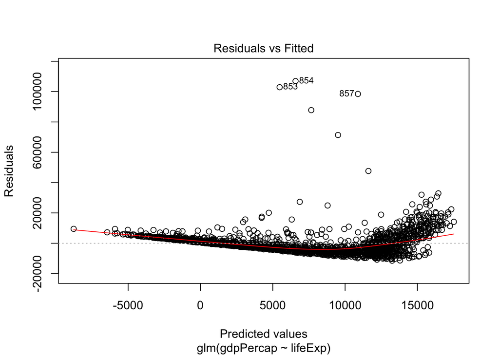

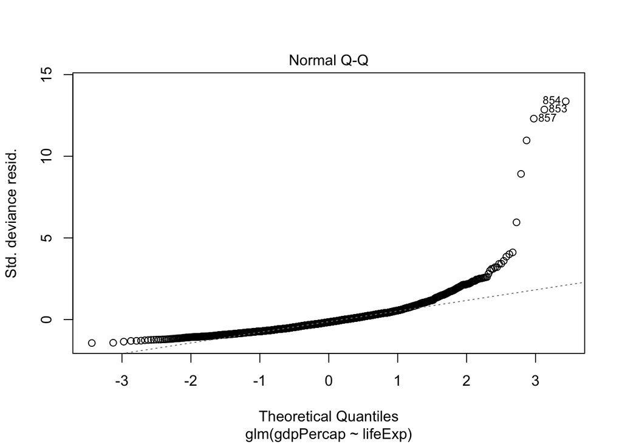

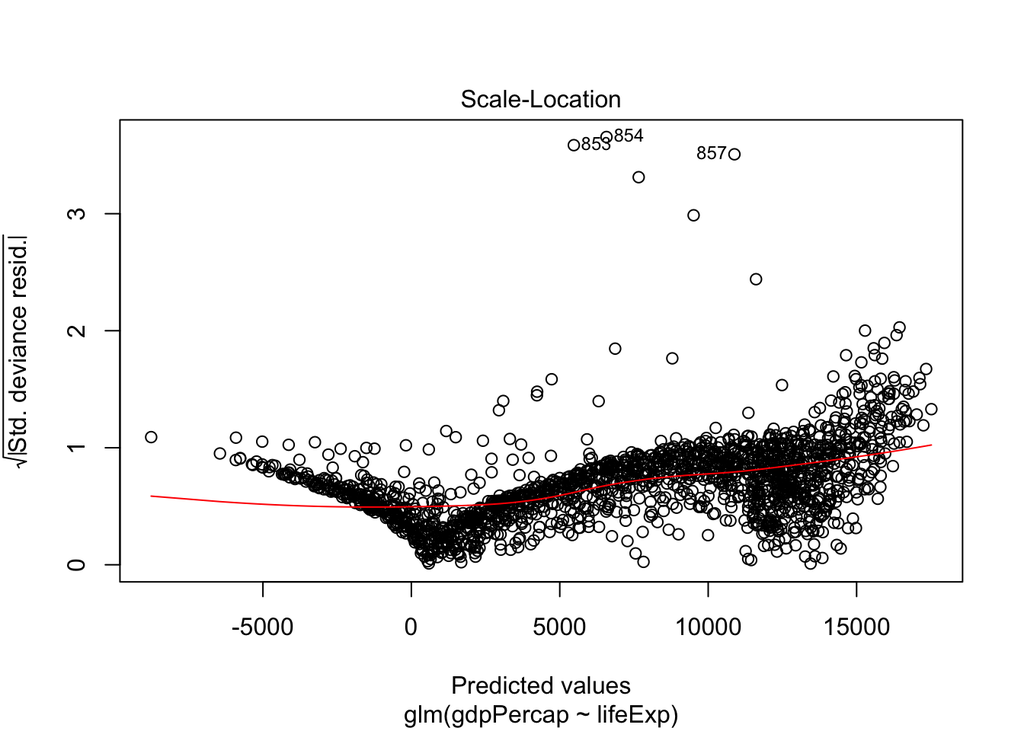

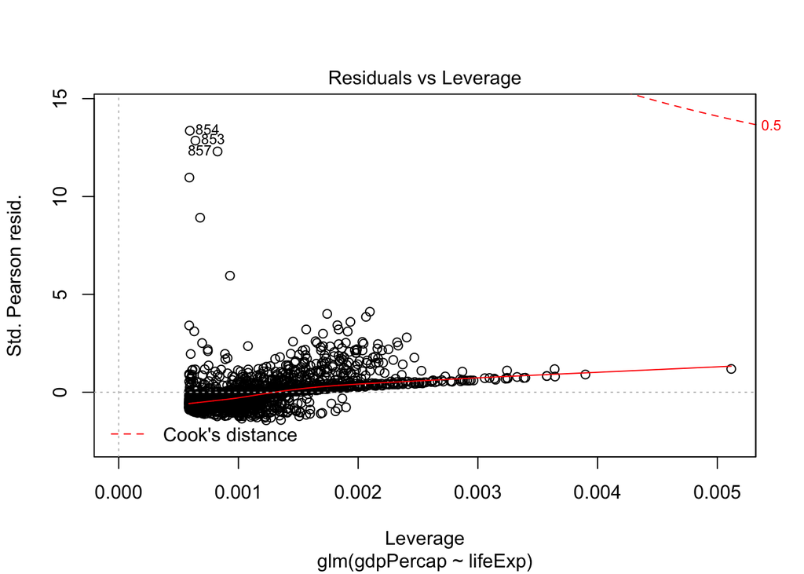

```r
plot(mod)
```

> **Challenge**

What kind of object is mod? Extract the residual degrees of freedom (hint: `attributes()` will help you).

Lists are often the returned value of a function in R. You can access items in that list the same way you would other lists, using [, [[, or $.

#### Data frames

Remember the data frames are lists underneath the hood, so similar rules apply. However, they are also two- dimensional objects: [ with one argument will act the same way as for lists, where each list element corresponds to a column. The resulting object will be a data frame:

```r
head(gapminder[3])
```

```
##   continent
## 1      Asia
## 2      Asia
## 3      Asia
## 4      Asia
## 5      Asia
## 6      Asia
```

Similarly, `[[` will act to extract a single column (as an atomic vector, not dataframe)

```r
head(gapminder[["lifeExp"]])
```

```
## [1] 28.801 30.332 31.997 34.020 36.088 38.438
```

And `$` provides a convenient shorthand to extract columns by name:

```r
head(gapminder$gdpPercap)
```

```
## [1] 779.4453 820.8530 853.1007 836.1971 739.9811 786.1134
```

With two arguments, `[` behaves the same way as for matrices:

```r
gapminder[1:3,]
```

```
##   X     country continent year lifeExp      pop gdpPercap
## 1 1 Afghanistan      Asia 1952  28.801  8425333  779.4453
## 2 2 Afghanistan      Asia 1957  30.332  9240934  820.8530
## 3 3 Afghanistan      Asia 1962  31.997 10267083  853.1007
```

If we subset a single row, the result will be a data frame (because the elements are mixed types):

```r
gapminder[3,]
```

```
##   X     country continent year lifeExp      pop gdpPercap
## 3 3 Afghanistan      Asia 1962  31.997 10267083  853.1007
```

But for a single column the result will be a vector (this can be changed with the third argument, drop = FALSE).

> **Practice Problems**
1. Extract observations collected for Africa `gapminder[gapminder$continent = 'Africa',]`
2. Extract all columns except 1 through to 4 `gapminder[,-1:4]`
3. Extract the rows where the life expectancy is longer the 80 years `gapminder[gapminder$lifeExp > 80]`
4. Extract the first row, and the 5th and 6th columns (lifeExp, gpdPercap). `gapminder[1, 5, 6]`
5. Advanced: extract rows that contain information for Cuba and Australia `gapminder[gapminder$country == 'Cuba' | 'Australia',]`
6. Why does `gapminder[1:20]` return an error? How does it differ from `gapminder[1:20, ]`?
7. Create a new data frame called gapminder_small that only contains rows 1 through 9 and 19 through 23. You can do this in one or two steps.

#### Key Points

- Indexing in R starts at 1, not 0.
- Access individual values by location using [].
- Access slices of data using [low:high].
- Access arbitrary sets of data using [c(…)].
- Use logical operations and logical vectors to access subsets of data.

#### **Acknowledgments**

*These pages were derived in part from:Benjamin Soltoff’s MACS 30500 - [Computing for the Social Sciences](https://cfss.uchicago.edu/) at University, and from Software Carpentry, licensed under the CC BY-NC 3.0 Creative Commons*